# final_project

Motivation: Primarily when analyzing stock run performance there is a tendency to focus on company specific returns. However, does the industry of which the stock belongs have any predictive capability? Each stock in the S&P 500 index is classified by a GICS Code [1]. The objective is to see whether or not GICS industry classifiers provide any additional predictive capabilities in predicting whether or not a stock will go up or down in the Q1 2019.

I will be relying on the IEX API, which unfortunately will be retired starting June 1, to provide historical stock price information over the past 5 years. To get a list for all 500 companies included in the S&P 500 index, I will first need to scrape the Wikipedia page for the S&P 500 to create a data frame containing ticker symbol, and GICS Sector, as IEX does not provide this information.

1. Wikipedia - S&P 500 Stock Composition

```r
url <- "https://en.wikipedia.org/wiki/List_of_S%26P_500_companies"
wiki_table <- url %>%
  read_html() %>%
  html_node(".wikitable") %>%
  html_table() %>%
  select(Symbol, Security, 'GICS Sector',CIK)
colnames(wiki_table)[3] <- 'GICS_sector'
colnames(wiki_table)[1] <- 'ticker'
wiki_table %>%
  as_tibble()
```

```
## # A tibble: 505 x 4
##    ticker Security                   GICS_sector                CIK
##    <chr>  <chr>                      <chr>                    <int>
##  1 MMM    3M Company                 Industrials              66740
##  2 ABT    Abbott Laboratories        Health Care               1800
##  3 ABBV   AbbVie Inc.                Health Care            1551152
##  4 ABMD   ABIOMED Inc                Health Care             815094
##  5 ACN    Accenture plc              Information Technology 1467373
##  6 ATVI   Activision Blizzard        Communication Services  718877
##  7 ADBE   Adobe Systems Inc          Information Technology  796343
##  8 AMD    Advanced Micro Devices Inc Information Technology    2488
##  9 AAP    Advance Auto Parts         Consumer Discretionary 1158449
## 10 AES    AES Corp                   Utilities               874761
## # … with 495 more rows
```

It was expected that the dataframe would contain 500 rows, as the index represents the 500 largest companies traded on both NYSE and NASDAQ. CIK (Central Index Key) is a unique identifier registered to each company by the SEC; this identifier will be helpful in identifying if there are any duplicate companies within wiki_table.

```r
wiki_table %>%
  group_by(CIK) %>%
  summarise(double_count = n()) %>%
  arrange(desc(double_count)) %>%
  slice(1:5) %>%
  left_join(wiki_table, by = "CIK") %>%
  select(ticker, Security, CIK) %>%
  as_tibble()
```

```
## # A tibble: 10 x 3
##    ticker Security                    CIK
##    <chr>  <chr>                     <int>
##  1 FOXA   Fox Corporation Class A 1308161
##  2 FOX    Fox Corporation Class B 1308161
##  3 UAA    Under Armour Class A    1336917
##  4 UA     Under Armour Class C    1336917
##  5 DISCA  Discovery Inc. Class A  1437107
##  6 DISCK  Discovery Inc. Class C  1437107
##  7 NWSA   News Corp. Class A      1564708
##  8 NWS    News Corp. Class B      1564708
##  9 GOOGL  Alphabet Inc Class A    1652044
## 10 GOOG   Alphabet Inc Class C    1652044
```

The additional 5 rows are related to companies having dual class shares included in the index. Companies may offer multiple classes of shares to investors, which can differ in rights and privileges related to corporate governance among other things [2].

2. IEX - Stock Prices

```r
root <- "https://api.iextrading.com/1.0/stock/"
```

To make parsing the data simple, I will be using the httr and jsonlite libraries. The below function makes a GET request, filtering on the needed columns (date and closing price). Finally a column for the ticker is added, which will allow for identification when adding to the broader dataframe holding all stock returns.

```r
get_prices <- function(ticker){
  filter <- "?filter=date,close"
  url <- paste(root, ticker, "/chart/5y",filter,sep="")
  temp <- GET(url) %>%
    content("text") %>%
    fromJSON %>%
    mutate(ticker = ticker)
  temp
}
```

To calculate 3-month return, I first split the time series data by yearly quarter. The decision for this was related to stocks submitting quarterly financial reports. How markets reacted to these disclosures would then be embedded in the price. By taking the average through the period, it reduces the noise of 1-day price action. After getting an average through the quarter, the data needed to be split between 2 time frames in order to calculate the 3-month return.

```r
calc_3month <- function(stock){
 temp_ticker <- stock$ticker[1]
 temp <- stock %>%
   mutate(yq = quarter(date, with_year=TRUE)) %>%
   group_by(yq) %>%
   summarise(average_close=mean(close))
 temp_1 <- slice(temp, 1:nrow(temp) - 1) %>% rowid_to_column()
 temp_2 <- slice(temp, 2:nrow(temp)) %>% rowid_to_column()
 temp_1_close <- pull(temp_1,average_close)
 temp_2_close <- pull(temp_2,average_close)
 return_3month <- (temp_2_close - temp_1_close) / temp_1_close
 temp_2 <- temp_2 %>%
   cbind(return_3month) %>%
   select(yq, return_3month) %>%
   mutate(ticker = temp_ticker)
 temp_2
}
```

3. S&P 500 DataFrame With the 2 functions needed to create the desired dataframe, I will iterate through each ticker from the wiki_table and call the functions, binding the returned prices to sp500. Afterwards I will sort by yearly quarter to make it more easily read.

```r
sp500_list <- pull(wiki_table, ticker)
sp500 <- calc_3month(get_prices(sp500_list[1]))
for(i in 2:length(sp500_list))
  sp500 <- rbind(sp500,calc_3month(get_prices(sp500_list[i])))
sp500 <- sp500 %>%
  arrange(yq)
as_tibble(sp500)
```

```
## # A tibble: 9,879 x 3
##       yq return_3month ticker
##    <dbl>         <dbl> <chr>
##  1 2014.       0.00618 MMM
##  2 2014.       0.0593  ABT
##  3 2014.       0.0267  ABBV
##  4 2014.       0.0973  ABMD
##  5 2014.      -0.0232  ACN
##  6 2014.       0.0664  ATVI
##  7 2014.       0.0422  ADBE
##  8 2014.      -0.0184  AMD
##  9 2014.       0.0336  AAP
## 10 2014.       0.0265  AES
## # … with 9,869 more rows
```

Before joining with the wiki_table, it would be helpful to get a brief summary of how stocks performed over the time period. However, the analysis must be kept to before 2019, as Q1 2019 is the period to be predicted.

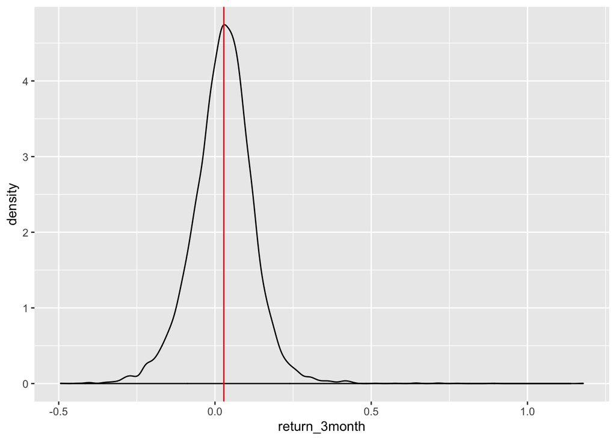

```r
sp500 %>%
  filter(yq < 2019) %>%
  ggplot(aes(return_3month)) +
  geom_density() +
  geom_vline(aes(xintercept=median(return_3month)), color="red")
```

As is apparent from the above, a little over half of stocks during the time period analyzed had a positive 3 month return.

Finally, we will add the GICS Sector from the wikitable and group the dataframe by GICS Sector.

```r
sp500 <- sp500 %>%
  left_join(wiki_table, by="ticker") %>%
  select(-c("CIK","Security"))

sp500$GICS_sector <- factor(sp500$GICS_sector)
as_tibble(sp500)
```

```
## # A tibble: 9,879 x 4
##       yq return_3month ticker GICS_sector
##    <dbl>         <dbl> <chr>  <fct>
##  1 2014.       0.00618 MMM    Industrials
##  2 2014.       0.0593  ABT    Health Care
##  3 2014.       0.0267  ABBV   Health Care
##  4 2014.       0.0973  ABMD   Health Care
##  5 2014.      -0.0232  ACN    Information Technology
##  6 2014.       0.0664  ATVI   Communication Services
##  7 2014.       0.0422  ADBE   Information Technology
##  8 2014.      -0.0184  AMD    Information Technology
##  9 2014.       0.0336  AAP    Consumer Discretionary
## 10 2014.       0.0265  AES    Utilities
## # … with 9,869 more rows
```

With sp500 now including GICS Sector, we are able to see the variability in 3-month returns by industry.

```r
summary_stats <- sp500 %>%
  filter(yq < 2019) %>%
  group_by(GICS_sector) %>%
  summarise(mean_return = mean(return_3month), sd_return = sd(return_3month)) %>%
  arrange(desc(mean_return))
summary_stats
```

```
## # A tibble: 11 x 3
##    GICS_sector            mean_return sd_return
##    <fct>                        <dbl>     <dbl>
##  1 Information Technology     0.0436     0.107
##  2 Health Care                0.0369     0.106
##  3 Utilities                  0.0277     0.0705
##  4 Financials                 0.0262     0.0844
##  5 Industrials                0.0254     0.0867
##  6 Consumer Staples           0.0218     0.0763
##  7 Real Estate                0.0214     0.0741
##  8 Consumer Discretionary     0.0192     0.106
##  9 Materials                  0.0173     0.109
## 10 Communication Services     0.0173     0.110
## 11 Energy                    -0.00654    0.134
```

Out of curiosity, let us see what the top performers within Information Technology.

```r
sp500 %>%
  filter(yq < 2019 & GICS_sector == 'Information Technology') %>%
  arrange(desc(return_3month)) %>%
  slice(1:10)
```

```
##        yq return_3month ticker            GICS_sector
## 1  2018.3     0.7751557    AMD Information Technology
## 2  2016.2     0.7092461    AMD Information Technology
## 3  2016.3     0.6431674    AMD Information Technology
## 4  2017.1     0.5137638    AMD Information Technology
## 5  2016.3     0.4351840   NVDA Information Technology
## 6  2016.4     0.4176648   NVDA Information Technology
## 7  2018.1     0.4120546    STX Information Technology
## 8  2015.4     0.3986535   NVDA Information Technology
## 9  2015.1     0.3785738   SWKS Information Technology
## 10 2016.3     0.3625386    STX Information Technology
```

Both Advanced Micro Devices (AMD) and Nvidia (NVDA) are strategically positioned in the current AI/ML euphoria.

An underlying principle that all investing follows, is that for taking on more risk (as measured by standard deviation) you should be rewarded with higher returns. It is hard to see if this relationship can be viewed at the industry level. However, it is clear that there are certain industries that had performed comparably but with differing risk levels. Further, Energy seemed to perform both terribly and have the highest level of risk. This is due to Energy being highly sensitive to commodity prices, which fluctuate cosiderably due to events outside of stock markets.

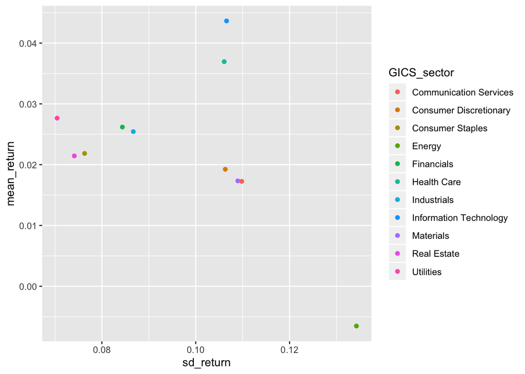

```r
summary_stats %>%
  ggplot(aes(sd_return, mean_return, color=GICS_sector)) +
  geom_point()
```

4. Creating Model and Extracting Outcome_Df With a finalized dataset, we can extract the outcome_df and design a statistical model to predict stock performance.

The outcome df will have a categorical outcome of 1 meaning up and 0 meaning down depending on the return for Q1 2019.

```r
outcome_df <- sp500 %>%
  filter(yq == '2019.1') %>%
  select(yq, ticker, return_3month) %>%
  mutate(direction = ifelse(return_3month > 0, 1, 0)) %>%
  select(ticker, direction)
outcome_df %>% as_tibble()
```

```
## # A tibble: 502 x 2
##    ticker direction
##    <chr>      <dbl>
##  1 MMM            1
##  2 ABT            1
##  3 ABBV           0
##  4 ABMD           0
##  5 ACN            0
##  6 ATVI           0
##  7 ADBE           1
##  8 AMD            1
##  9 AAP            0
## 10 AES            1
## # … with 492 more rows
```

Now we will filter the sp500 dataframe to the required time frame, everything before 2019, and spread yq as columns with respect to return_3month. This will allow the model to use each quarterly time frame per ticker, and rejoin the outcome_df.

```r
final_df <- sp500 %>%
  filter(yq < 2019) %>%
  spread(yq, return_3month) %>%
  left_join(outcome_df, by="ticker")
final_df %>% as_tibble()
```

```
## # A tibble: 501 x 21
##    ticker GICS_sector `2014.3` `2014.4` `2015.1` `2015.2` `2015.3` `2015.4`
##    <chr>  <fct>          <dbl>    <dbl>    <dbl>    <dbl>    <dbl>    <dbl>
##  1 A      Health Care  -0.0113  -0.0100  0.00571  0.0286  -0.0861   0.0252
##  2 AAL    Industrials  -0.0625   0.0978  0.181   -0.100   -0.0976   0.0578
##  3 AAP    Consumer D…   0.0336   0.121   0.0500  -0.00906  0.135    0.00248
##  4 AAPL   Informatio…   0.0790   0.114   0.115    0.0634  -0.0792  -0.0212
##  5 ABBV   Health Care   0.0267   0.144  -0.0347   0.0897   0.00446 -0.107
##  6 ABC    Health Care   0.0517   0.132   0.176    0.123   -0.0663  -0.0610
##  7 ABMD   Health Care   0.0973   0.245   0.721    0.224    0.326   -0.0368
##  8 ABT    Health Care   0.0593   0.0351  0.0595   0.0509  -0.0134  -0.0581
##  9 ACN    Informatio…  -0.0232   0.0480  0.0766   0.0814   0.0387   0.0736
## 10 ADBE   Informatio…   0.0422  -0.0110  0.0642   0.0460   0.0389   0.108
## # … with 491 more rows, and 13 more variables: `2016.1` <dbl>,
## #   `2016.2` <dbl>, `2016.3` <dbl>, `2016.4` <dbl>, `2017.1` <dbl>,
## #   `2017.2` <dbl>, `2017.3` <dbl>, `2017.4` <dbl>, `2018.1` <dbl>,
## #   `2018.2` <dbl>, `2018.3` <dbl>, `2018.4` <dbl>, direction <dbl>
```

Before fitting the model, the dataframe must be split between training and testing. This is accomplished by grouping final_df by the predictor variable (direction), and then sampling half from each group. The train data will just be whatever has not been included in test_df.

```r
set.seed(1234)
test_df <- final_df %>%
  group_by(direction) %>%
  sample_frac(0.5) %>%
  ungroup()

train_df <- final_df %>%
  anti_join(test_df, by="ticker")
```

With the data evenly partitioned between test and train, a logistic regression model can be fitted for both simple and with GICS_sector. The model will be fitted on all parameters excluding ticker.

```r
library(knitr)
simple_fit <- glm(direction ~ . -ticker -GICS_sector, data=train_df , family='binomial')
simple_fit %>% tidy() %>% arrange(p.value) %>% select(term, p.value, everything())
```

```
## # A tibble: 19 x 5
##    term         p.value estimate std.error statistic
##    <chr>          <dbl>    <dbl>     <dbl>     <dbl>
##  1 `2016.2`    0.000119    8.50      2.21     3.85
##  2 `2018.4`    0.000920    8.17      2.47     3.31
##  3 `2018.3`    0.0341     -5.33      2.51    -2.12
##  4 (Intercept) 0.0400      0.766     0.373    2.05
##  5 `2015.3`    0.0454      4.91      2.45     2.00
##  6 `2014.4`    0.0493      6.05      3.08     1.97
##  7 `2015.1`    0.0625     -4.58      2.46    -1.86
##  8 `2016.4`    0.0646     -4.02      2.17    -1.85
##  9 `2017.2`    0.183       3.34      2.51     1.33
## 10 `2017.3`    0.205       3.28      2.59     1.27
## 11 `2015.2`    0.217       3.30      2.67     1.23
## 12 `2016.1`    0.300       2.18      2.11     1.04
## 13 `2015.4`    0.387      -1.93      2.23    -0.866
## 14 `2018.2`    0.606       1.20      2.33     0.515
## 15 `2017.4`    0.702       0.817     2.13     0.383
## 16 `2017.1`    0.739       0.867     2.60     0.334
## 17 `2014.3`    0.868      -0.584     3.52    -0.166
## 18 `2016.3`    0.910      -0.283     2.51    -0.113
## 19 `2018.1`    0.962      -0.110     2.28    -0.0481
```

When judging by p.value alone, with a statistical significance of 0.05, it would appear that several of the quarterly variables hold predictive capability.

```r
sector_fit <- glm(direction ~ . -ticker, family='binomial', data=train_df)
sector_fit %>% tidy() %>% arrange(p.value) %>% select(term, p.value, everything())
```

```
## # A tibble: 29 x 5
##    term                              p.value estimate std.error statistic
##    <chr>                               <dbl>    <dbl>     <dbl>     <dbl>
##  1 `2016.2`                          0.00128     8.53      2.65      3.22
##  2 `2018.4`                          0.00138     8.47      2.65      3.20
##  3 `2016.4`                          0.00986    -6.72      2.60     -2.58
##  4 `2015.1`                          0.0251     -6.37      2.84     -2.24
##  5 `2015.2`                          0.0414      6.62      3.25      2.04
##  6 `2017.3`                          0.0444      6.25      3.11      2.01
##  7 GICS_sectorReal Estate            0.0488      2.54      1.29      1.97
##  8 GICS_sectorConsumer Discretionary 0.0588      2.06      1.09      1.89
##  9 GICS_sectorIndustrials            0.0628      2.02      1.08      1.86
## 10 GICS_sectorMaterials              0.100       2.20      1.34      1.64
## # … with 19 more rows
```

In addition to the time-frame variables being of statistical significance, Real Estate as a categorical variable is also included.

[1] <- https://www.msci.com/gics  
[2] <- https://www.investopedia.com/terms/s/share_class.asp